# Water Collection System in Mexico City - 2022

Rainwater harvesting systems are a prominent water collection method in Mexico

python

Author

Jesus L. Monroy

Published

Mar, 2024

Abstract

Rainwater harvesting is a sustainable and effective way to manage water resources in Mexico. By promoting water conservation and increasing water security, these systems offer a path towards a more water-resilient future.

[figure not shown]

Rainwater harvesting systems are a prominent water collection method in Mexico, especially in areas facing water scarcity.

These systems, called **“Sistemas de Captación de Agua de Lluvia”** (SCALL) offer several benefits:

- Reduced strain on aquifers: By collecting rainwater, these systems decrease reliance on groundwater sources, which are often overexploited.
- Improved water security: Especially in peri-urban areas, rainwater harvesting provides a more dependable water source, particularly during dry spells.
- Cost-effective solution: Rainwater harvesting can significantly reduce water bills for households.
- Empowering communities: Programs like “Aqua a tu Casa” in Mexico City train women to install and maintain these systems, fostering economic opportunities.

### Watch the video

[video not shown]

### Environment setting

```python
import numpy as np
import pandas as pd
import matplotlib.pyplot as plt
import seaborn as sns
import altair as alt
import duckdb as db
import folium
from folium.plugins import Fullscreen
from itables import init_notebook_mode
init_notebook_mode(all_interactive=True)
import warnings
warnings.filterwarnings('ignore')
plt.style.use('ggplot')
```

```python
conn = db.connect('my_database.db')
```

```python
df = conn.sql('select * from water_collection').df()
```

```python
conn.close()
```

```python
df.head()
```

expediente

pueblo

scall_col

territorial

fecha_instalacion

capacidad

alcaldia

colonia_datos

latitud

longitud

[figure not shown]

### Dataset preview

```python
# Dataset preview
from itables import show
df.columns = ['file', 'village', 'scall', 'territory', 'facility_date', 'capacity', 'alcaldia', 'suburb',
              'latitude','longitude']

show(df, lengthMenu=[10, 25, 50, 100,])
```

file

village

scall

territory

facility_date

capacity

alcaldia

suburb

latitude

longitude

[figure not shown]

### Descriptive Statitistics

```python
df.describe(include='number')
```

capacity

latitude

longitude

[figure not shown]

```python
df['facility_date'] = pd.to_datetime(df['facility_date'])
```

```python
start = df['facility_date'].min().strftime('%d/%m/%Y')
```

```python
end = df['facility_date'].max().strftime('%d/%m/%Y')
```

```python
print(f'The research period comprehends from {start} until {end}.')
```

```
The research period comprehends from 02/05/2022 until 30/11/2022.
```

### Installed Capacity by Alcaldia

```python
alcaldias = (
    df.groupby('alcaldia')['capacity']
        .agg('sum')
        .to_frame()
        .reset_index()
        .sort_values('capacity')
)
```

```python
alcaldias['capacity'] = alcaldias['capacity']/1_000_000
```

```python
alt.Chart(alcaldias).mark_bar(size=50, color='#760000', filled=True).encode(
    y=alt.Y('alcaldia:N').sort('-x'),
    x=alt.X("capacity:Q").title('Capacity (million of liters)'),
    tooltip=['alcaldia', 'capacity'],
).properties(
    width=780,
    height=450,
    title='Installed Capacity by Alcaldia',
).configure_axisY(
    labelFontSize=14,
    titleFontSize=16,
    title='',
).configure_axisX(
    grid=True,
    labelFontSize=16,
    titleFontSize=16,
    #title='Capacity (million of liters)',
).configure_title(
    fontSize=20,
    font='Helvetica Neue',
).configure_view(
    fill='#ececec',
)
```

[interactive chart not shown]

### Installed Capacity by Village

```python
villages = (
    df.groupby('village')['capacity']
        .agg('sum')
        .to_frame()
        .reset_index()
        .sort_values('capacity')
)
```

```python
villages['capacity'] = villages['capacity']/1_000_000
```

```python
alt.Chart(villages).mark_bar(size=10, color='#760000', filled=True).encode(
    y=alt.Y('village:N').sort('-x'),
    x=alt.X("capacity:Q").title('Capacity (million of liters)'),
    tooltip=['village', 'capacity'],
).properties(
    width=780,
    height=500,
    title='Installed Capacity by Village',
).configure_axisY(
    labelFontSize=9,
    titleFontSize=14,
    title='',
).configure_axisX(
    grid=True,
    labelFontSize=16,
    titleFontSize=16,
    #title='Capacity (million of liters)',
).configure_title(
    fontSize=20,
    font='Helvetica Neue',
).configure_view(
    fill='#ececec',
)
```

[interactive chart not shown]

### Installed Capacity by Month

```python
months = df.groupby(pd.Grouper(key='facility_date', freq="ME"))['capacity'].sum().to_frame().reset_index()
```

```python
months['capacity'] = months['capacity']/1_000_000
```

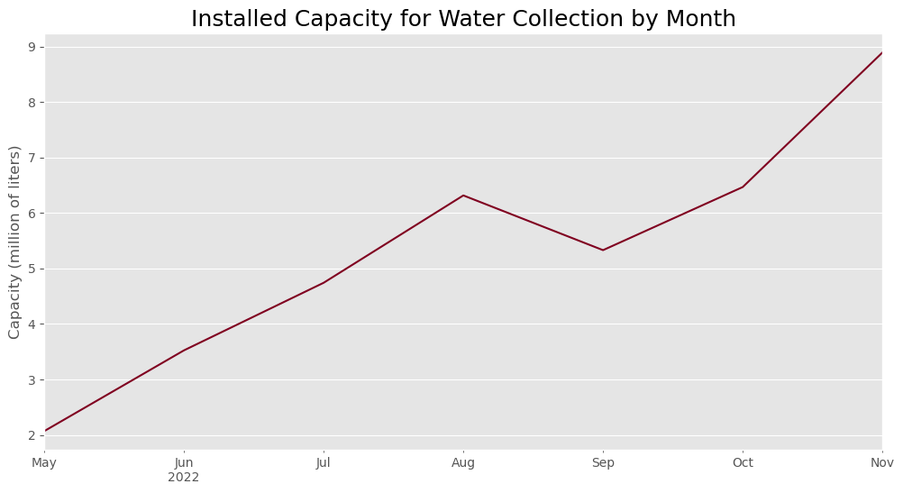

```python
months.plot(x='facility_date', y='capacity', legend=None, figsize=(12,6), color='#800020')
plt.title('Installed Capacity for Water Collection by Month', fontsize=(18))
plt.ylabel('Capacity (million of liters)')
plt.xlabel('')
plt.show()
```

### Villages with Installations

```python
zones = (
    df.groupby('village')[['capacity','latitude','longitude']]
        .agg({'capacity':'sum','latitude':'mean','longitude':'mean'})
        .reset_index(drop=False)
)
```

```python
#zones.plot.scatter(x='latitude',y='longitude', figsize=(12,7))
#plt.title('Location of Villages with Installations', fontsize=16)
#plt.show()
```

```python
map = folium.Map(
    location=[19.26, -99.11],
    zoom_start=11.49,
    control_scale=False,
)
# Layers
Zones = folium.FeatureGroup(name='<u><b>Instalacion</b></u>', show=True)
map.add_child(Zones)
#draw marker with symbol you want at base
my_symbol_css_class= """ <style>
.fa-mysymbol3:before {
    font-family: Arial;
    font-weight: bold;
    font-size: 12px;
    color: white;
    background-color:'';
    border-radius: 10px;
    white-space: pre;
    content: 'P';
    }
</style>
        """
# the below is just add above  CSS class to folium root map
map.get_root().html.add_child(folium.Element(my_symbol_css_class))
# then we just create marker and specific your css class in icon like below
for i in zones.index:
   html=f"""
        <p style="font-size: 14px;">{zones.iloc[i]['village']}</font></p>
        <p style="font-size: 14px;">Capacity: {zones.iloc[i]['capacity']}</font></p>
        """
   iframe = folium.IFrame(html=html, width=200, height=130)
   popup = folium.Popup(iframe, max_width=250)
   folium.Marker(
        location = [zones.iloc[i]['latitude'], zones.iloc[i]['longitude']],
        icon = folium.Icon(color='darkred', prefix='fa', icon='fa-mysymbol3'),
        popup = popup,
        tooltip = zones.iloc[i]['village']
    ).add_to(Zones)
folium.plugins.Fullscreen().add_to(map)
```

```
<folium.plugins.fullscreen.Fullscreen at 0x31269f020>
```

```python
map
```

[interactive chart not shown]

**NoteInfo**

You can hover over the icons on the map to get further information and zoom in or out.

### References

- Portal de Datos Abiertos Ciudad de México. Sedema.
- [Dataset](https://datos.cdmx.gob.mx/dataset/scall)

## Contact

**Jesus L. Monroy**  
*Economist & Data Scientist*

[Medium](https://medium.com/@jesuslm) | [Linkedin](https://www.linkedin.com/in/j3sus-lm) | [Twitter](https://x.com/j3suslm)